# CH_18_TE

Steph Jordan

3/27/2022

## “How does it work?” Section

## Question 1

The assumption that nothing else changes over time except for the treatment is necessary for event studies models, but not for difference in difference models. In event studies, we have to assume that whatever was going on before treatment would have continued going on if not for the treatment. We use the difference between the outcome in that counter-factual scenario and the outcome that actually occurred to estimate the treatment effect. However, in DID, since we have a control group, we don’t have to assume the pre-treatment trends continued over time.

## Question 2

There may be events affecting everyone that would change the outcome from before-treatment to after-treatment anyway (B)

## Question 3

1. It is possible that in the windows prior to the pre-treatment period, the control group and treatment group had diverging trends, and the values of the dependent variable happened to converge in the specific pre-treatment window examined. In this case, the trends would continue to diverge post treatment (independent of the treatment). Therefore, this is a scenario in which, despite the dependent variable’s values being the same across groups during the pre-treatment window, the parallel trends assumption fails.
2. Our effect would be off by whatever difference between the control and treatment groups there is that is due to this natural divergence associated with their opposing trends, rather than any differences associated with the treatment itself.

## Question 4

1. The rates of change for the treatment and control groups in the pre-treatment period are somewhat different: the treated group has more variable slope (ranging from slightly positive to slightly negative), while the control group slope is consistently positive. Therefore, the parallel trends assumption does not appear to hold.
2. We will underestimate the treatment effect, because if we falsely assume parallel trends then we will end up finding a difference between treatment and control that is less than that which would be the case if the parallel trends assumption actually held. Imagine we had a perfect control group (ie a counterfactual to the treated group that continued along the same trend that the treated group was following pre-treatment). The control group line post treatment would be below the control group line used in the example. The estimate of the effect would be larger in this case (in the case that parallel trends actually held), and our estimate, if we falsely assume parallel trends held, would therefore be an underestimate.

## Question 5

We need to perform a prior test to assess the parallel trends assumption before assuming DID is a good way to estimate this effect. If the parallel trends assumption holds, we can estimate a DID model.

## Question 6

DID = (9-5) - (7.5-6) = 4-1.5 = 2.5

## “How is it performed?” Section

## Question 1

1. A set of fixed effects for state, and for year, and an interaction between “is 2016” and “is a treated state”. (iv)
2. The coefficient on the interaction term for whether the state is currently treated

## Question 2

Assuming that the rate of change of test scores trends was the same in treated and non-treated schools in the pre-treatment period, the effect of laptops on test scores was 5.034 points, and this effect was statistically significant at the 95% level.

## Question 3

This test is performed in order to assess whether the trends in rates of change prior to treatment are similar for treatment and control groups; this is necessary for DID estimates because if the trends weren’t similar before treatment, then we won’t be able to claim that treatment is the only factor that influenced differences between treatment and control groups after treatment. If the coefficient on B3 is significant, we know that there is a significant difference associated with being in the treatment vs control groups in the pre-treatment period. If the test produces an estimate that suggests that there is a significant difference associated with being in the treated vs control group, even though the treatment has yet to be administered, then we know there are significant differences between control and treatment prior to the treatment intervention, which undermines our ability to claim that post-treatment differences between treatment and control are entirely due to treatment (undermines the parallel trends assumption).

## Question 4

1. The pre-treatment differences between treatment and control outcomes are large in the periods prior to treatment, meaning the parallel trends assumption is violated.
2. DID = ((0.5)+(1)+(3))/3 = 1.5

## Question 5

If the treatment effect is dynamic or if the treatment effect varies across groups (ie treatment on group 1 is different from treatment on group 2), then we will fail to get the correct treatment effect estimate. If the treatment effect gets stronger over time, then the treated group in period 1 would be trending upwards over time and the treated group in period 2 wouldn’t. Therefore, the parallel trends assumption would fail. Or, if the treatment effect differed between groups, being larger or smaller on the first treatment group than on the second treatment group, then we would also have a mis-estimation of the treatment effect.

## Question 1

Load the data set `sourdough_trends.csv` and look through the data. In R or Python, save the dataset as `sr`.

Then, limit the data to just the variables of interest: `date`, `hits` (the Google Trends index), and `keyword`, the search term we’re examining.

Finally, convert the “date” variable to a usable date.

```r
library(dplyr)
sr <- read.csv('https://raw.githubusercontent.com/NickCH-K/TheEffectAssignments/main/sourdough_trends.csv')
```

```r
sr <- sr|>select(c('date', 'hits', 'keyword'))
```

```r
sr <- sr|> mutate (date=as.Date(date))
```

## Question 2

Make a line graph with `date` on the x-axis and `hits` on the y-axis, with a separate line for each `keyword`. Also add a vertical line for the “start of the pandemic” which we’ll decide for our purposes is March 15, 2020.

```r
library(ggplot2)
```

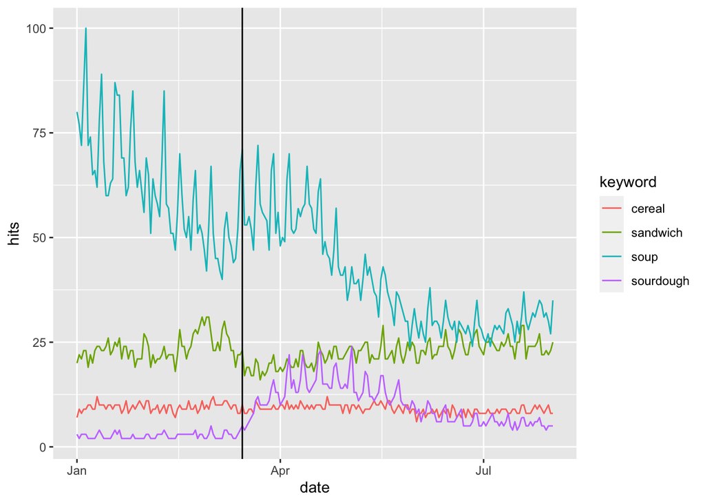

```r
eventdate <- as.Date('2020-03-15')

ggplot(data=sr, aes(x=date, y=hits, color=keyword)) +
  geom_line()+
  geom_vline(xintercept=eventdate)
```

## Question 3

Looking at your graph from problem 2, comment on (a) whether it looks like the lockdown had an effect on the popularity of sourdough, (b) the shape that effect takes (i.e. is it a permanent increase in popularity? Temporary?), (c) whether you might be concerned about any of the control groups we’ve chosen

## Question 4

Create a “Treated” indicator that’s equal to 1 for sourdough and 0 otherwise (or True/False, either way). Do a test of whether the prior trends (keeping March 15 as the “treatment date”) differ between the treated and control groups, using a linear trend and doing a statistical significance test at the 95% level. Then, if you were concerned about any of the control groups in question 3c, drop any you were concerned about (and keep them dropped for the rest of the assignment) and rerun the test.

Write a line commenting on whether you can reject equal prior trends in your model(s).

```r
sr <- sr|> mutate(treated=ifelse(keyword=='sourdough', 1, 0))
```

Select all observations pre- March 15

```r
sr_prior <- sr|>filter(date<as.Date('2020-03-15'))
```

Estimate the model

```r
library(lme4)
library(fixest)
library(modelsummary)
m1 <- lm(hits ~ date*treated + date + treated,
    data = sr_prior)
```

```r
msummary(m1, stars = c('*' = .1, '**' = .05, '***' = .01))
```

|  | Model 1 |
| --- | --- |
| (Intercept) | 2365.049** |
|  | (1166.315) |
| date | −0.128** |
|  | (0.064) |
| treated | −2475.932 |
|  | (2332.630) |
| date × treated | 0.134 |
|  | (0.127) |
| Num.Obs. | 296 |
| R2 | 0.287 |
| R2 Adj. | 0.279 |
| AIC | 2627.8 |
| BIC | 2646.3 |
| Log.Lik. | −1308.919 |
| F | 39.134 |
| RMSE | 20.29 |

* p < 0.1, ** p < 0.05, *** p < 0.01

The coefficient on datextreated is not significant, so there is not a threat to the parallel trends assumption.

Removing soup and sandwich control groups

```r
sr_prior <- sr_prior|> filter(keyword!='soup' & keyword!='sandwich')
```

Rerunning model

```r
m2 <- lm(hits ~ date*treated + date + treated,
    data = sr_prior)
```

```r
msummary(m2, stars = c('*' = .1, '**' = .05, '***' = .01))
```

|  | Model 1 |
| --- | --- |
| (Intercept) | −90.495 |
|  | (89.668) |
| date | 0.005 |
|  | (0.005) |
| treated | −20.387 |
|  | (126.810) |
| date × treated | 0.001 |
|  | (0.007) |
| Num.Obs. | 148 |
| R2 | 0.937 |
| R2 Adj. | 0.936 |
| AIC | 394.9 |
| BIC | 409.9 |
| Log.Lik. | −192.449 |
| F | 712.227 |
| RMSE | 0.90 |

* p < 0.1, ** p < 0.05, *** p < 0.01

The coefficient on datextreated is still not significant, so we don’t have a threat to the parallel trends assumption.

Removing soup and sandwich from main dataset for future analyses

```r
sr <- sr|> filter(keyword!='soup' & keyword!='sandwich')
```

## Question 5

Create a `month` variable by shifting the `date` variable back 15 days (so that the treatment day is the first day of the month) and then taking the month of the resulting date. Also create an `After` variable equal to 1/0 (or True/False) if the date is March 15 or afterwards.

*Language-specific instructions*:

- In R, load the **lubridate** package if you haven’t already. You can then use `-days()` to subtract days from the date, and `month()` to get the month from the date. Then use `feols()` from **fixest** to estimate the model.

```r
library(lubridate)
sr <- sr|> mutate(month=month(date-14))
```

```r
sr <- sr|> mutate(after=ifelse(date>as.Date('2020-03-15'), 1, 0))
```

Then, take a look at the values of `month` you get and how they line up with `date`, and subtract a number from `month` so that the last period just before treatment (Feb 16-Mar 14) is 0. (Also, change the Jan 1-14 month so it’s one less than the Jan 15-Feb 14 month)

```r
sr <- sr|> mutate(month=month-2)
```

```r
sr <- sr|> mutate(month = if_else(month > 9, -2, month))
```

```r
sr <- sr|> mutate(treated = if_else(keyword=='sourdough' & after==1, 1, 0))
```

Then, use two-way fixed effects to estimate the difference-in-difference estimate of the effect of lockdown on sourdough popularity with `keyword` and `month` fixed effects, and standard errors clustered at the `keyword` level.

```r
# feols clusters by the first
# fixed effect by default, no adjustment necessary
m3 <- feols(hits ~ treated | keyword + month,
    data = sr)
```

```r
msummary(m3, stars = c('*' = .1, '**' = .05, '***' = .01))
```

|  | Model 1 |
| --- | --- |
| treated | 8.097*** |
|  | (0.026) |
| Num.Obs. | 428 |
| R2 | 0.662 |
| R2 Adj. | 0.654 |
| R2 Within | 0.427 |
| R2 Pseudo |  |
| AIC | 1932.5 |
| BIC | 1973.1 |
| Log.Lik. | −956.264 |
| Std.Errors | by: keyword |
| FE: keyword | X |
| FE: month | X |

* p < 0.1, ** p < 0.05, *** p < 0.01

The estimated effect of lockdown on sourdough search popularity is 8.1.

## Question 6

Now, let’s allow the effect to be dynamic over time. Estimate a difference-in-difference model allowing the effect to differ by month (using `month = 0` as a reference period), with standard errors clustered at the keyword level, and show the results.

```r
#Interact month with being in the treated group using
# the fixest i() function, which also lets us specify
# a reference period (using the numeric version of Quarter)

m4 <- feols(hits ~ i(month, treated, ref = 0) |
            keyword + month, data = sr)
```

```
## Variables 'month::-2:treated' and 'month::-1:treated' have been removed because of collinearity (see $collin.var).
```

```r
msummary(m4, stars = c('*' = .1, '**' = .05, '***' = .01))
```

|  | Model 1 |
| --- | --- |
| month = 1 × treated | 9.747** |
|  | (0.203) |
| month = 2 × treated | 12.542*** |
|  | (0.058) |
| month = 3 × treated | 8.195*** |
|  | (0.058) |
| month = 4 × treated | 4.575*** |
|  | (0.058) |
| month = 5 × treated | 3.386** |
|  | (0.058) |
| Num.Obs. | 428 |
| R2 | 0.774 |
| R2 Adj. | 0.767 |
| R2 Within | 0.617 |
| R2 Pseudo |  |
| AIC | 1768.2 |
| BIC | 1825.1 |
| Log.Lik. | −870.120 |
| Std.Errors | by: keyword |
| FE: keyword | X |
| FE: month | X |

* p < 0.1, ** p < 0.05, *** p < 0.01

The estimated effect is significant throughout, but largest right after treatment (in month 1 and month 2 following treatment).

## Question 7

Make a graph demonstrating the results of your dynamic difference-in-differences model. Describe both what the effect looks like and also whether this graph gives you any concerns about prior trends violations.

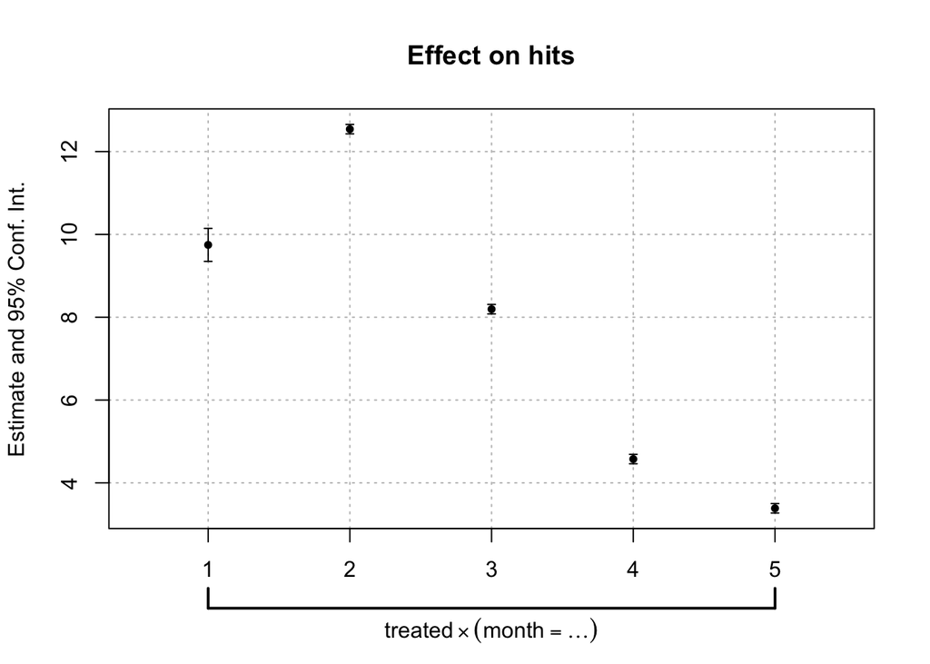

```r
coefplot(m4)
```

[figure not shown]